```
title: "EN EL CONTEXTO DEL METODO PARAMETRICO COMPARATIVA DE DISTRIBUCIONES EN TERMINOS DE VaR (Value at Risk).(Intermediate Version)"
author: Miguel Martinez
output:
  pdf_document:
    latex_engine: xelatex
    df_print: kable
    includes:
      in_header: "preamble.tex"
```

# INTRODUCCION

Este trabajo es un estudio de las diferentes distribuciones que permiten calcular el Valor en Riesgo VaR (“Value at Risk”) de los activos que componen el índice IBEX35, principal índice bursátil de referencia de la bolsa española.

Para ello se han utilizado datos diarios del índice desde el año 2000 hasta 2019.

El valor en riesgo (VaR) es un estadístico que mide y cuantifica el máximo de pérdida esperada en una cartera de activos en un periodo de tiempo a un nivel de confianza determinado. Desde que el comité de Basilea de Supervisión Bancaria del Banco de Pagos Internacionales requiere a las instituciones financieras cumplir con los requerimientos de capital en base a las estimaciones del Valor en Riesgo (VaR), esta medida se ha convertido en una herramienta básica del riesgo de mercado.

En este trabajo utilizaremos datos diarios del índice IBEX35 sobre 20 años (2000-2019) como ya hemos indicado. Con esta medida determinaremos la extensión de las pérdidas potenciales de los activos que componen el índice. Se mide el VaR evaluando la cantidad de pérdidas potenciales, la probabilidad de que ocurra para una cantidad de pérdida y el horizonte temporal.

Por ejemplo, si una cartera de activos tiene un diario 5% Valor en Riesgo de 100.000 € significa que hay un 5% de probabilidad que la cartera de activos pierda mas de 100.000 € en el periodo de un dia.

# METODOLOGIA

Para estimar este valor utilizaremos el método paramétrico comparando cuatro posible distribuciones estadísticas que puede seguir el VaR:

- Distribución normal.
- Distribución t-student.
- Distribución de Error Generalizada.
- Distribución de Error Generalizada Asimétrica.

Una vez calculado el VaR en las diferentes distribuciones validaremos las estimaciones mediante el ‘backtesting’, procedimiento que nos dirá cuan buenas son esas estimaciones y por tanto qué distribución se ajusta mejor para estimar el VaR.

En el marco de las técnicas paramétricas, podemos estimar el VaR como $VaR_{t}=\mu_{t}+\hat\sigma_{t}k_{\alpha}$ donde $\mu_{t}$ representa la media, $\hat\sigma_{t}$ la desviación standard y $k_{\alpha}$ denota el correspondiente quantil de la distribución de los rendimientos standarizados a un nivel de confianza de $1-\alpha$.

Finalmente, una vez calculada la varianza, estimamos las distribuciones de los rendimientos estandarizados bajo cada una de las distribuciones consideradas: normal, t-student, error generalizada, error generalizada asimétrica.

Las funciones de densidad de las distribuciones con las que trabajaremos son las siguientes:

**FUNCIONES DENSIDAD DISTRIBUCIONES**

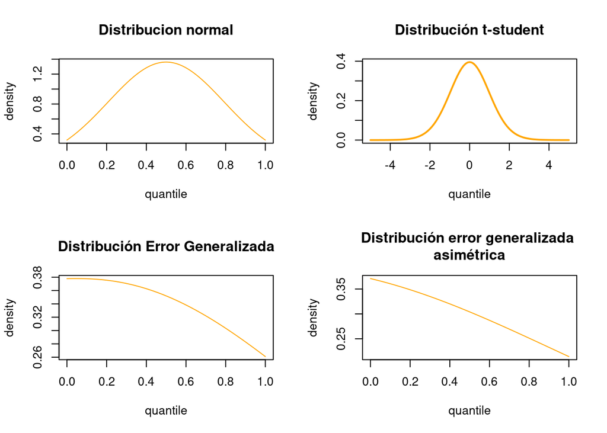

Asi pues, en primer lugar calcularemos el VaR. Tenemos una excepción cuando $r_{t+1}=VaR(\alpha)$ Seguidamente, comprobamos la precisión de las estimaciones de VaR mediante el test de Kupiec:

$$LRuc (Test\ de\ Kupiec) = 2*log(\frac{\hatα ^ x ( 1− α ) ^ {N-x}}{\hatα ^ x ( 1− α ) ^ {N-x}})$$

Adicionalmente, evaluamos la magnitud de las pérdidas experimentadas. Seguimos la función de pérdida propuesta por López. Con esta especificación, la función de pérdida asigna una especificación cuadrática cuando las pérdidas observadas de la cartera de activos, excede el VaR estimado:

$LF = 1+(r_{t}-VaR( α ))^{2}$ si $r_{t}<VaR( α )$ ; $0$ si $r_{t}>VaR( α )$

El término cuadrático asegura que los fallos grandes son penalizados mas que los fallos pequeños.